# staRoxy: Oxylipidomics Abundance Data Analysis Pipeline

[figure not shown]

Pedro Henrique F. Jordão & Eduardo M. Reis

30 March 2026 | **Version 0.1.0

## Abstract

`staRoxy` is a dedicated R package designed to streamline oxylipidomics abundance data analysis. It provides functions for data cleaning, normalization, statistical modeling, and integrated visualization for exploratory and differential analyses, as well as specialized tools for profile comparison and precursor identification and enrichment. Although originally developed for oxylipin profiling [1], it can be readily adapted for other omics datasets, including transcriptomics, proteomics, and metabolomics. This vignette describes the recommended workflow and core functionalities of the package.

## Funding

The development of the `staRoxy` package has been partially supported by the São Paulo Research Foundation (FAPESP; grant number 2025/00242-1) and FAPESP/CEPID-Redoxoma (grant number 2013/07937-8).

## Acknowledgments

We thank Nicholas A. Brown, Daniela Bizinelli, Giuseppe G. F. Leite, Vinícius A. Pereira, and other friends for their valuable feedback and discussions during the development of the package. Special thanks to Cynthia D. Diniz for the logo design.

## Citation

If you use `staRoxy` in published research, please cite: [1]

Several other R packages are available for lipidomics and metabolomics analyses, including [MetaboAnalystR](https://www.metaboanalyst.ca/docs/RTutorial.xhtml), [xcms](https://bioconductor.org/packages/release/bioc/html/xcms.html), [MSnbase](https://bioconductor.org/packages/release/bioc/html/MSnbase.html), [LipidMS](https://cran.r-project.org/web/packages/LipidMS/index.html), and [lipidr](https://www.bioconductor.org/packages/release/bioc/html/lipidr.html), among others.

## Overview

Lipidomics experiments generate quantitative matrices in which lipids are measured across multiple biological conditions. Final concentration units are typically nmol/ml or nmol/mg, although they may vary depending on the analytical method or adaptations used. Proper analysis requires systematic preprocessing, normalization, quality control, and statistical modeling.

The `staRoxy` package provides a reproducible framework for oxylipidomics abundance data analysis, originally developed for an oxylipin profiling protocol [1]. It integrates:

- Structured data import and validation.
- Missing-value filtering and diagnostics.
- Log<sub>2</sub> transformation.
- Quality control diagnostics.
- Exploratory data analysis.
- Oxylipin profile analysis.
- Differential abundance analysis using linear modeling.
- Correlation analysis.
- Loading pattern dissimilarity analysis.
- Precursor identification and enrichment analysis.

The workflow is designed to move from raw abundance matrices to biologically interpretable results in a standardized and transparent manner.

## Setup, Initialization, and Data Import

First, install the package. `staRoxy` is currently not available on the Comprehensive R Archive Network (CRAN). The development version can be installed via BiocManager, which will also install the required dependencies:

```
if (!require("BiocManager", quietly = TRUE))
    install.packages("BiocManager")

BiocManager::install("pefjordao/staRoxy", build_vignettes = TRUE)
```

Then, load the package:

```r
library(staRoxy)
```

The `staRoxy` package requires two input files:

1. A **oxylipid abundance** data frame (`data_path`). Supported formats include `.xlsx`, `.xls`, `.csv` (comma or semicolon separated), `.tsv`, `.txt`, or `.dat`.
2. A **metadata** table (`meta_path`) describing sample annotations.

### Input Data Structure

#### Abundance Data Frame File

- First column: `"oxylipin"` — oxylipin identifiers.
- Remaining columns: sample names.
- Values: quantitative abundance measurements.
- **Missing (`NA`), non-detected (below the limit of detection, LOD), or non-quantified values (below the limit of quantification, LOQ) should be left empty.**
- Zero values are automatically converted to `NA`.

#### Metadata file

- First column: `"sample"` — sample identifiers (must match column names in abundance data frame).
- Second column: `"group"` — biological condition.
- Optional additional columns: covariates (e.g., batch, sex, age).

## Example Data

The `staRoxy` package provides three example datasets for testing and demonstration:

- **Cellular Pellets:** Data from RAW 264.7 murine macrophage pellets comparing two harvesting methods: mechanical scraping and enzymatic treatment (Data: `data_oxy_pellet`, Metadata: `metadata_oxy_pellet`).
- **Culture Supernatant:** Secreted oxylipin profiles from the same RAW 264.7 samples, including a control group (Data: `data_oxy_supernatant`, Metadata: `metadata_oxy_supernatant`).
- **Blood Plasma:** A biological study on an Amyotrophic Lateral Sclerosis (ALS) mouse model (SOD1-G93A) at asymptomatic and symptomatic stages, published by Chaves-Filho et al. (2023) [2] (Data: `data_oxy_plasma`, Metadata: `metadata_oxy_plasma`).

**Note:** All datasets were analyzed using `staRoxy` (version 0.1.0) as described in the original protocol [1]. For the purposes of this vignette, we will focus on the cellular pellet dataset.

You can load these datasets into your environment using the `data` function:

```r
data(data_oxy_pellet)
data(metadata_oxy_pellet)
```

## Creating the staRoxy Object

The pipeline begins by importing the abundance data frame and the metadata, ensuring proper matching between samples and their annotations. If either file (abundance data frame or metadata) contains samples not present in the other, these will be automatically removed and reported to the user. This is performed using the `read_oxy` function, which creates an object that stores the data and is used throughout the downstream analysis pipeline:

```r
staRoxy_object <- read_oxy(data_path = data_oxy_pellet,
                           meta_path = metadata_oxy_pellet)
```

```
#>
#> ── staRoxy Data Summary ────────────────────────────────────────────────────────
#> ✔ Successful upload of 7 oxylipins across 12 samples.
#>
#> ── Experimental Groups: ──
#>
#> • Scraper: n = 6
#> • Trypsin: n = 6
#> ────────────────────────────────────────────────────────────────────────────────
```

## Missing Value Filtering and Log<sub>2</sub> Transformation

Before statistical modeling, the data must be filtered and transformed to meet the assumptions of linear models. The `filter_oxy` function provides three filtering strategies:

1. **Type I:** $\ge$`prop` valid values in **AT LEAST** one group.
2. **Type II:** $\ge$`prop` valid values across **ALL** samples.
3. **Type III:** strict mode. **NO** missing values allowed.

The proportion of valid values can be adjusted using the `prop` argument (default = 0.5).

```r
staRoxy_object <- filter_oxy(staRoxy_object,
                             type = "I",
                             prop = 0.5)
```

```
#> ℹ Type I: >50% valid values in AT LEAST one group.
#> ✔ Filtering complete: 7 oxylipins remaining.
```

**Note:** Type I filtering favors the retention of oxylipins that are exclusive to one of the analyzed groups.

After filtering, `transform_oxy` performs:

- Log<sub>2</sub> transformation of abundance values.
- Removal of lipids with zero variance or full missing values (`NA`).

```r
staRoxy_object <- transform_oxy(staRoxy_object)
```

```
#> ✔ Log2 transformation complete.
#> ℹ All oxylipins retained: no zero variance or full NA profiles detected.
```

## Quality Control

Before conducting statistical tests, it is essential to evaluate the global structure and robustness of the data. This step ensures that the data meets the assumptions required for robust linear modeling.

### Data Distribution

The function `check_data_distribution` provides a diagnostic quality-control report by:

- Assessing sample size per group.
- Identifying critical group imbalance.
- Evaluating data scale compatibility with log<sub>2</sub> transformation.
- Emitting warnings regarding potential statistical power limitations.

This function assesses whether the data have been appropriately transformed to the log<sub>2</sub> scale using the **Pearson’s skewness coefficient** ($\gamma_1$) [3], which measures the asymmetry of the distribution relative to its mean:

$$\gamma_1 =
E\left[\left(\frac{X-\mu}{\sigma}\right)^3\right] = \frac{\sum_{i=1}^{n}
(x_i - \bar{x})^3 / n}{s^3}$$

Where:

- $x_i$: abundance of an individual oxylipin in sample $i$.
- $\bar{x}$: sample mean.
- $n$: number of observations.
- $s$: standard deviation.
- $(x_i - \bar{x})^3$: third central moment; preserves sign to indicate skew direction (positive or negative tail).
- $|\gamma_1| < 1.2$: acceptable distribution (likely already log<sub>2</sub>-transformed).
- $|\gamma_1| > 1.2$: strong skewness; log<sub>2</sub> transformation is recommended if not already performed (to avoid double transformation).

To assess group imbalance, this function evaluates the ratio between the largest and smallest group sizes in order to identify potential biases in linear modeling. The imbalance ratio ($R$) [4] is defined as:

$$R =
\frac{\max(n_{group})}{\min(n_{group})}$$

```r
check_data_distribution(staRoxy_object)
```

```
#>
#> ── Model Advisor Report ────────────────────────────────────────────────────────
#> ℹ Testing distribution symmetry using Pearson's skewness coefficient (γ1).
#> ℹ Scale Check: Distribution is reasonably symmetric (γ1 = 0.76).
#> ✔ Data scale looks appropriate for linear modeling (likely log-transformed).
#> ℹ Checking sample sizes per group:
#> ✔ Group 'Scraper': n = 6. Sample size is adequate.
#> ✔ Group 'Trypsin': n = 6. Sample size is adequate.
#> ℹ Imbalance Ratio (R): 1x.
#> ✔ Experimental design is balanced (R <= 2.0). Assumptions are likely met.
#> ────────────────────────────────────────────────────────────────────────────────
```

If $R > 2.0$ (e.g., one group is at least twice the size of another), the function issues a warning indicating that caution is required when interpreting variance-related results, as unbalanced designs may affect the homogeneity of dispersion and impact downstream statistical analyses.

### Missing Data Diagnostic

After applying Type I or Type II filtering, abundance data may still contain missing values (`NA`). Therefore, it is important to assess the origin of these missing values, distinguishing between **Missing Not At Random (MNAR)**, typically associated with the **Limit of Detection (LOD)**, and **Missing At Random (MAR)**, often arising from experimental or technical variability.

The `plot_na_diagnostic` function provides two visualization modes. With `mode = "cor"`, it generates a scatter plot relating **Mean Log<sub>2</sub> Abundance** to the **Proportion of Missing Values**. A negative correlation, where oxylipins with a higher proportion of `NA` are observed at lower abundances, suggests an MNAR pattern:

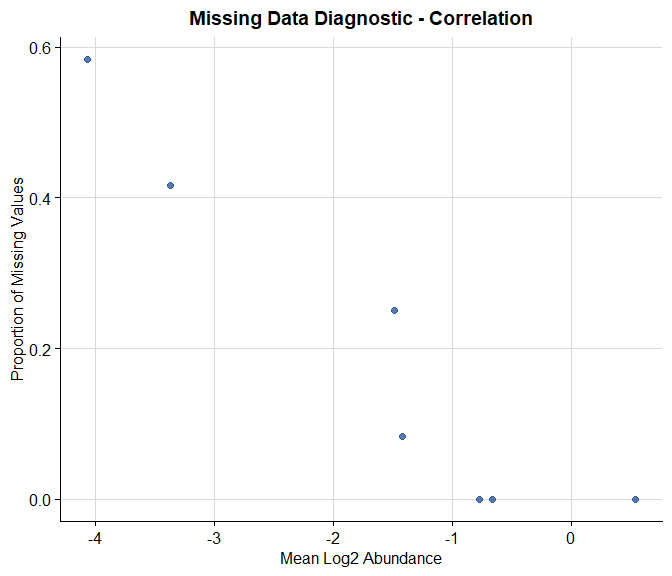

```r
plot_na_diagnostic(staRoxy_object,
                   mode = "cor")
```

Alternatively, with `mode = "dist"`, the function generates plots relating **Log<sub>2</sub> Abudance** to either **Density** or **Cumulative Fraction**. If the distribution of oxylipins with `NA` values (`TRUE`) shows higher density or is shifted toward lower abundances, this indicates that these features are primarily detected at low concentrations and become missing below the LOD, consistent with an MNAR pattern:

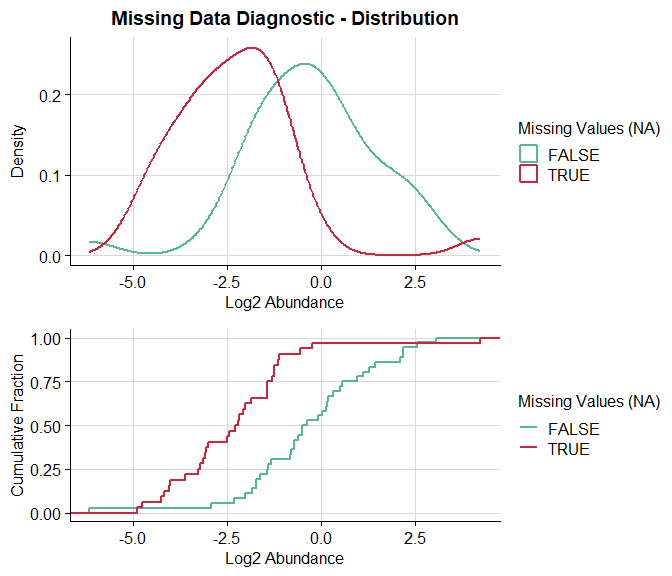

```r
plot_na_diagnostic(staRoxy_object,
                   mode = "dist")
```

**Based on this diagnostic, it is possible to determine how missing values should be handled in downstream functions that require explicit `NA` treatment, such as `plot_pca_oxy`, `plot_heatmap_oxy`, `profile_test`, `limma_oxy`, and `loading_dissimilarity` (see below). In each function, the `na_method` argument defines the imputation strategy to be used, either `"minprob"` (for MNAR-type missingness) or `"rf"` (for MAR-type missingness).**

## Exploratory Analysis

Exploratory analysis allows inspection of the overall structure of the data prior to hypothesis testing and may also help identify oxylipins with distinct patterns between experimental groups.

### Analyzed and Exclusive Oxylipins

The function `get_exclusives_oxy` identifies oxylipins that were detected in only one of the analyzed groups. **Note that data imputation is performed only in analyses that require it, and the original data frame remains unchanged throughout.**

```r
get_exclusives_oxy(staRoxy_object)
```

```
#>
#> ── Exclusive Oxylipins Detection ───────────────────────────────────────────────
#> ✔ Group 'Scraper': 1 exclusive oxylipin found.
#>   - 1a,1b-dihomo-PGE2
#> ℹ Group 'Trypsin': No exclusive oxylipins found.
#> ────────────────────────────────────────────────────────────────────────────────
```

Conversely, the function `get_analyzed_oxy` returns the names of all oxylipins retained after filtering:

```r
get_analyzed_oxy(staRoxy_object)
```

```
#> ℹ Found 7 oxylipins detected in the dataset.
#> [1] "12-HHTrE"          "10-HOA"            "9-HETE"
#> [4] "PGE2"              "20-carboxy-LTB4"   "TXB3"
#> [7] "1a,1b-dihomo-PGE2"
```

### Descriptive Statistics

Descriptive statistics can be computed using the `descriptives_oxy` function, which returns oxylipin identifiers, experimental groups, number of valid values, number of missing values (`NA`), mean, median, standard deviation, standard error of the mean, and coefficient of variation. The `sort_by` argument allows sorting the results in decreasing order based on a selected metric:

```r
descriptives_oxy(staRoxy_object,
                 sort_by = "mean")
```

```
#>
#> ── Descriptive Statistics ──────────────────────────────────────────────────────
#> ℹ Sorting by: "mean" | Groups: "Scraper, Trypsin"
#>            Feature   group n_valid n_na  mean median   sd  sem cv_perc
#>               TXB3 Scraper       6    0  1.67   1.66 1.08 0.44   64.65
#>               PGE2 Scraper       6    0  0.15   1.20 3.17 1.29 2166.36
#>           12-HHTrE Scraper       5    1 -0.40  -1.25 2.65 1.18 -660.29
#>               TXB3 Trypsin       6    0 -0.59  -0.23 1.48 0.61 -251.84
#>             9-HETE Scraper       6    0 -0.72  -0.66 0.80 0.33 -111.34
#>             9-HETE Trypsin       6    0 -0.82  -0.71 0.61 0.25  -74.79
#>    20-carboxy-LTB4 Scraper       6    0 -1.43  -1.33 1.05 0.43  -73.17
#>               PGE2 Trypsin       6    0 -1.46  -1.58 0.71 0.29  -48.52
#>    20-carboxy-LTB4 Trypsin       3    3 -1.58  -1.42 0.54 0.31  -33.97
#>           12-HHTrE Trypsin       6    0 -2.27  -2.14 0.72 0.29  -31.66
#>             10-HOA Scraper       3    3 -3.35  -3.61 0.96 0.55  -28.58
#>             10-HOA Trypsin       4    2 -3.38  -3.06 1.04 0.52  -30.67
#>  1a,1b-dihomo-PGE2 Scraper       5    1 -4.06  -4.04 0.54 0.24  -13.21
#>  1a,1b-dihomo-PGE2 Trypsin       0    6   NaN     NA   NA   NA      NA
#> ────────────────────────────────────────────────────────────────────────────────
```

The `group` argument can be used to restrict the output to a specific experimental group:

```r
descriptives_oxy(staRoxy_object,
                 group = "Trypsin")
```

```
#>
#> ── Descriptive Statistics ──────────────────────────────────────────────────────
#> ℹ Sorting by: "feature" | Groups: "Trypsin"
#>            Feature   group n_valid n_na  mean median   sd  sem cv_perc
#>             10-HOA Trypsin       4    2 -3.38  -3.06 1.04 0.52  -30.67
#>           12-HHTrE Trypsin       6    0 -2.27  -2.14 0.72 0.29  -31.66
#>  1a,1b-dihomo-PGE2 Trypsin       0    6   NaN     NA   NA   NA      NA
#>    20-carboxy-LTB4 Trypsin       3    3 -1.58  -1.42 0.54 0.31  -33.97
#>             9-HETE Trypsin       6    0 -0.82  -0.71 0.61 0.25  -74.79
#>               PGE2 Trypsin       6    0 -1.46  -1.58 0.71 0.29  -48.52
#>               TXB3 Trypsin       6    0 -0.59  -0.23 1.48 0.61 -251.84
#> ────────────────────────────────────────────────────────────────────────────────
```

### Principal Component Analysis

**Principal Component Analysis (PCA)** is a fundamental step in omics data analysis. It provides a global overview of:

- Sample clustering.
- Group separation.
- Outlier sample detection.
- Overall data quality.

The function `plot_pca_oxy` generates a publication-ready PCA plot allowing customization of colors and graphical parameters:

```
#> ! Removed 1 oxylipin with zero variance/data in at least one group.
#> ✔ Filtering complete: 6/7 oxylipins retained.
#> ℹ Imputing via 'minprob': assuming missingness is due to low concentration (MNAR).
```

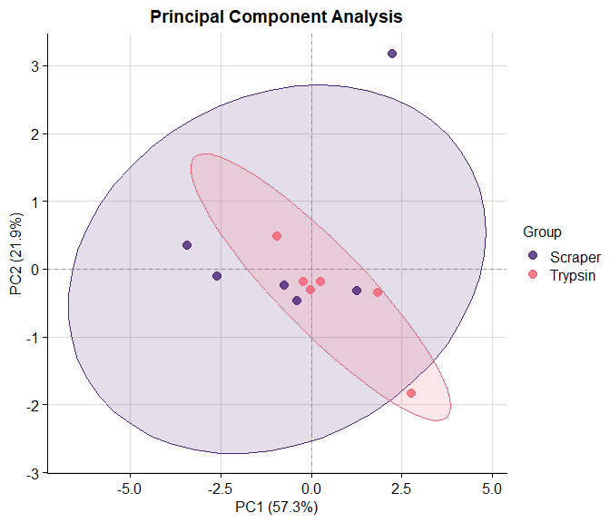

```r
# Define group-specific colors for visualization
my_colors <- c("Trypsin" = "#F65F72", "Scraper" = "#492376")

plot_pca_oxy(staRoxy_object,
             colors = my_colors)
```

**Note:** Missing values (`NA`) are handled through a multi-step quality control pipeline. Oxylipins are retained only if they have valid measurements in at least 50% of samples (≥50%) in at least one experimental group (user-adjustable). Missingness is assessed via the `plot_na_diagnostic` function, distinguishing between Missing Not At Random (MNAR) and Missing At Random (MAR). For MNAR-type oxylipins, missing values values are imputed using the group-wise arithmetic mean (equivalent to the geometric mean on the log<sub>2</sub> scale). When an entire group lacks detection, values are imputed as below the Limit of Detection (LOD) or failed to meet the Limit of Quantification (LOQ) criteria, using the global minimum for that oxylipin, with stochastic noise sampled from a normal distribution (10% of the global standard deviation) to preserve variance and ensure numerical stability. For MAR-type oxylipins, missing values are imputed using a Random Forest approach (via the `missForest` package), leveraging the global metabolic profile. Group-exclusive oxylipins and those with insufficient variance across groups are excluded from multivariate analyses by default, preventing artificial clustering and ensuring that models reflect robust biological patterns.

### Z-score Heatmap

The function `plot_heatmap_oxy` generates a publication-ready heatmap, allowing customization of colors and graphical parameters.

The function applies a $Z$-score transformation per oxylipin, placing all oxylipins on the same scale. In the resulting heatmap:

- A value of $0$ represents the mean abundance of that oxylipin
- **Positive** values indicate values above the mean
- **Negative** values indicate values below the mean

```
#> ! Removed 1 oxylipin with zero variance/data in at least one group.
#> ✔ Filtering complete: 6/7 oxylipins retained.
#> ℹ Imputing via 'minprob': assuming missingness is due to low concentration (MNAR).
```

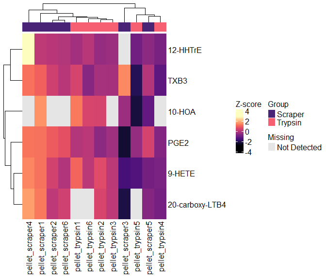

```r
plot_heatmap_oxy(staRoxy_object,
                 colors = my_colors)
```

**Note:** Missing values (`NA`) are handled through a multi-step quality control pipeline. Oxylipins are retained only if they have valid measurements in at least 50% of samples (≥50%) in at least one experimental group (user-adjustable). Missingness is assessed via the `plot_na_diagnostic` function, distinguishing between Missing Not At Random (MNAR) and Missing At Random (MAR). For MNAR-type oxylipins, missing values values are imputed using the group-wise arithmetic mean (equivalent to the geometric mean on the log<sub>2</sub> scale). When an entire group lacks detection, values are imputed as below the Limit of Detection (LOD) or failed to meet the Limit of Quantification (LOQ) criteria, using the global minimum for that oxylipin, with stochastic noise sampled from a normal distribution (10% of the global standard deviation) to preserve variance and ensure numerical stability. For MAR-type oxylipins, missing values are imputed using a Random Forest approach (via the `missForest` package), leveraging the global metabolic profile. Group-exclusive oxylipins and those with insufficient variance across groups are excluded from multivariate analyses by default, preventing artificial clustering and ensuring that models reflect robust biological patterns.

For hierarchical clustering, a fully imputed matrix is used to compute Euclidean distances. Original `NA` positions are then restored for visualization and displayed in a distinct color (default: `"grey90"`), distinguishing true non-detections from low-abundance measurements. `NA` values can be hidden from the plot using the `hide_na = TRUE` argument. However, note that hierarchical clustering will be recomputed accordingly:

```
#> ! Removed 1 oxylipin with zero variance/data in at least one group.
#> ✔ Filtering complete: 6/7 oxylipins retained.
#> ℹ Imputing via 'minprob': assuming missingness is due to low concentration (MNAR).
```

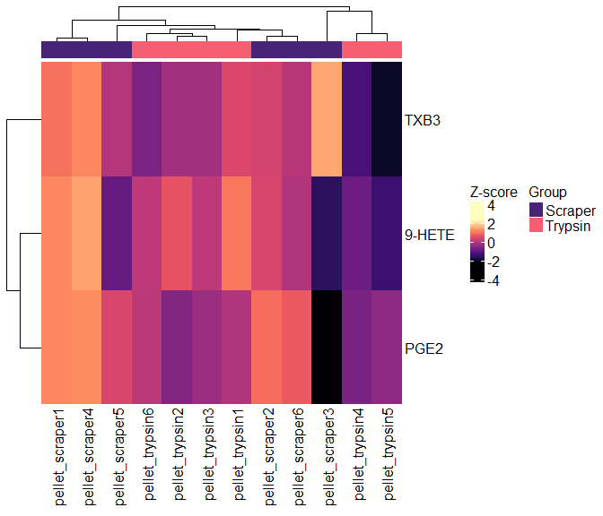

```r
plot_heatmap_oxy(staRoxy_object,
                 colors = my_colors,
                 hide_na = TRUE)
```

The function also allows control of the $Z$-score range displayed in the heatmap using the `z_cap` argument:

```
#> ! Removed 1 oxylipin with zero variance/data in at least one group.
#> ✔ Filtering complete: 6/7 oxylipins retained.
#> ℹ Imputing via 'minprob': assuming missingness is due to low concentration (MNAR).
```

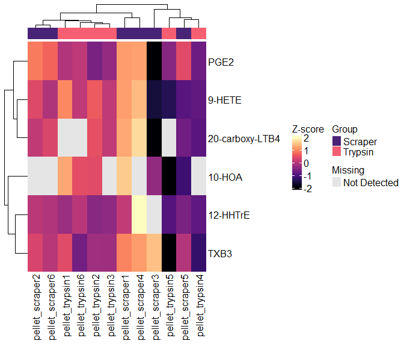

```r
plot_heatmap_oxy(obj = staRoxy_object,
                 colors = my_colors,
                 z_cap = 2)
```

## Oxylipin Profile Analysis

The function `profile_test` allows direct comparison of oxylipin abundance patterns across experimental groups, providing a multivariate overview of oxylipidomic signatures.

The data are standardized so that each oxylipin has a mean of $0$ and a variance of $1$ ($Z$-score scaling). This step is essential because oxylipins present at very high concentrations could otherwise dominate the analysis, masking biologically relevant signals from lower-abundance molecules.

The function then performs a **PERMANOVA** analysis [5] to test whether the global oxylipin composition differs between experimental groups. This test provides the following metrics:

- $R^2$ (explained variance): indicates the proportion of the total variation in the dataset that is explained by the group structure (e.g., an $R^2$ of 0.40 means that 40% of the differences in oxylipin profiles are due to the experimental groups).
- $P$-value: represents the probability of observing a difference between groups as large as (or larger than) the one obtained, assuming the null hypothesis is true. This is calculated via non-parametric permutations (default = 10000), determining if the “clustering” of samples is statistically significant.

When more than two groups are present and the global test is statistically significant, the function automatically performs pairwise PERMANOVA comparisons with **Bonferroni** correction, allowing identification of the specific groups responsible for the observed differences.

**Note:** Missing values (`NA`) are handled through a multi-step quality control pipeline. Oxylipins are retained only if they have valid measurements in at least 50% of samples (≥50%) in at least one experimental group (user-adjustable). Missingness is assessed via the `plot_na_diagnostic` function, distinguishing between Missing Not At Random (MNAR) and Missing At Random (MAR). For MNAR-type oxylipins, missing values values are imputed using the group-wise arithmetic mean (equivalent to the geometric mean on the log<sub>2</sub> scale). When an entire group lacks detection, values are imputed as below the Limit of Detection (LOD) or failed to meet the Limit of Quantification (LOQ) criteria, using the global minimum for that oxylipin, with stochastic noise sampled from a normal distribution (10% of the global standard deviation) to preserve variance and ensure numerical stability. For MAR-type oxylipins, missing values are imputed using a Random Forest approach (via the `missForest` package), leveraging the global metabolic profile. Group-exclusive oxylipins and those with insufficient variance across groups are excluded from multivariate analyses by default, preventing artificial clustering and ensuring that models reflect robust biological patterns.

For visualization, if `plot = TRUE`, the function generates a **PCoA (Principal Coordinates Analysis)** plot based on **Euclidean distance**, which should produce results equivalent to those obtained with PCA. This visualization summarizes the behavior of oxylipin profiles across conditions and is particularly useful for identifying coordinated changes in oxylipid mediators and for comparing global oxylipidomic signatures between biological groups:

```
#> ! Removed 1 oxylipin with zero variance/data in at least one group.
#> ✔ Filtering complete: 6/7 oxylipins retained.
#> ℹ Imputing via 'minprob': assuming missingness is due to low concentration (MNAR).
#>
#> ── Multivariate Profile Analysis (PERMANOVA) ───────────────────────────────────
#> ℹ Groups: Scraper, Trypsin | Oxylipins: 6 | Permutations: 10000
#> ℹ Total Variance Explained (R²): 0.146 | P-value: 0.151
#> ────────────────────────────────────────────────────────────────────────────────
```

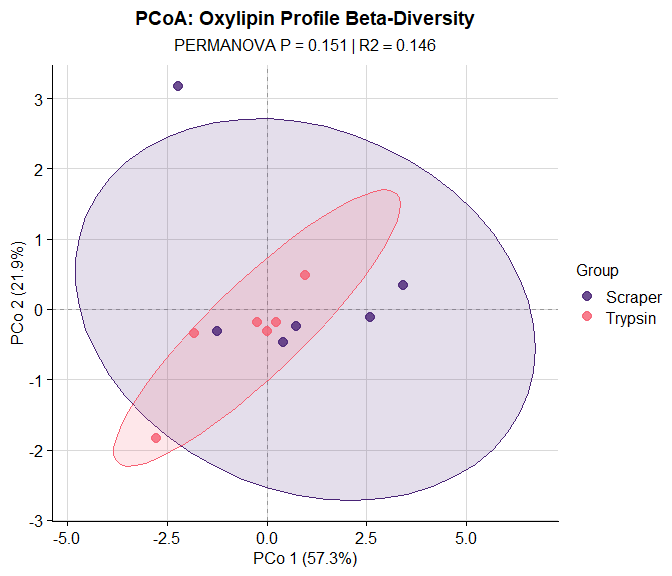

```r
profile_test(staRoxy_object,
             colors = my_colors,
             plot = TRUE)
```

## Differential Abundance Analysis

This section demonstrates how to perform differential abundance analysis of oxylipins between experimental groups in order to identify **Differentially Abundant Oxylipins (DAO)**.

The function `limma_oxy` uses the `limma` **(Linear Models for Microarray Data)** framework [6], which is a gold standard for the analysis of experiments with relatively small sample sizes. This framework applies an **empirical Bayes** approach that, in simple terms, borrows information across all oxylipins to stabilize variance estimates and improve the robustness of statistical tests. More details can be found in the original publication.

This function automatically fits a linear model for each oxylipin and generates all possible pairwise comparisons between experimental groups:

```r
stats <- limma_oxy(staRoxy_object)
```

```
#> ! Removed 1 oxylipin with zero variance/data in at least one group.
#> ✔ Filtering complete: 6/7 oxylipins retained.
#> ℹ Imputing via 'minprob': assuming missingness is due to low concentration (MNAR).
#> ✔ limma differential analysis complete.
```

To inspect the comparisons performed between experimental groups (referred to as “contrasts”), the function `list_contrasts` can be used:

```r
list_contrasts(stats)
```

```
#>
#> ── Experimental Contrasts ──────────────────────────────────────────────────────
#> ℹ Found 1 comparison in this analysis:
#> • Contrast 1: Scraper vs. Trypsin
#> ────────────────────────────────────────────────────────────────────────────────
```

Next, it is possible to visualize the **Log<sub>2</sub> Fold-change (Log2FC)**, **Standard Error of the Mean (SEM)**, and **adjusted** $P$-values (**Benjamini–Hochberg** correction) using the function `plot_rank_oxy`:

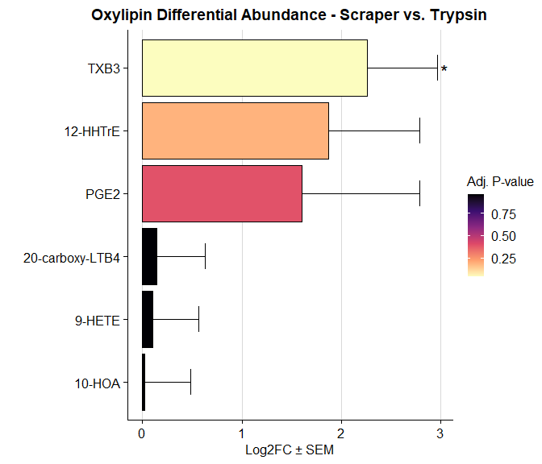

```r
plot_rank_oxy(stats,
              contrast = 1,
              top_n = 15,
              rank_by = "logFC")
```

By default, the function ranks oxylipins according to the absolute Log<sub>2</sub>FC, but they can also be ranked according to the adjusted $P$-value:

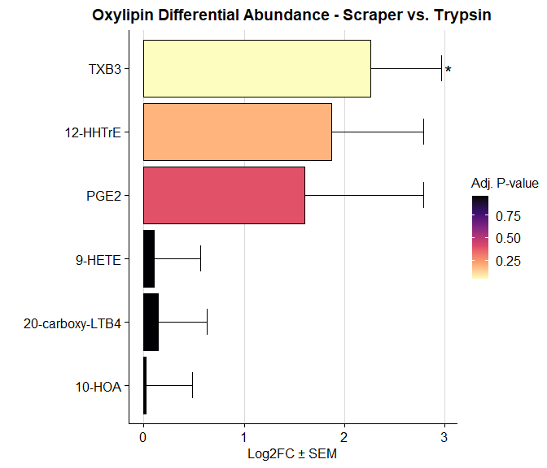

```r
plot_rank_oxy(stats = stats,
              contrast = 1,
              top_n = 15,
              rank_by = "p")
```

Another way to visualize oxylipin abundance across groups is through boxplots and violin plots. The function `plot_violin_oxy` allows visualization of the abundance of a selected oxylipin across all experimental groups, typically displayed on the log<sub>2</sub> scale, with customizable colors and graphical parameters:

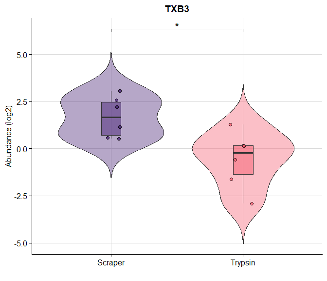

```r
plot_violin_oxy(staRoxy_object,
                stats,
                oxylipin = "TXB3",
                colors = my_colors,
                show_sig = TRUE,
                sig_y_nudge = 0.4)
```

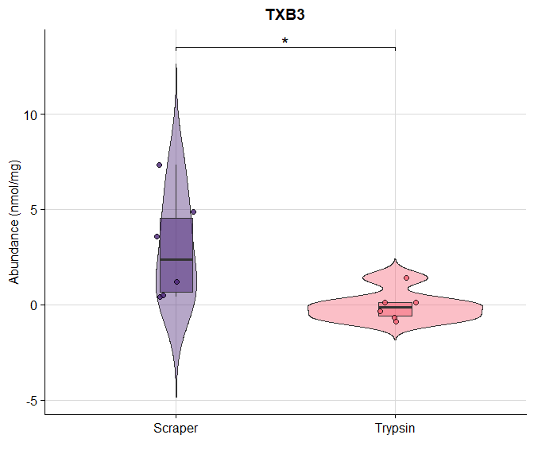

```r
plot_violin_oxy(staRoxy_object,
                stats,
                oxylipin = "TXB3",
                colors = my_colors,
                show_sig = TRUE,
                sig_y_nudge = 0.6,
                log_scale = FALSE,
                unit = "nmol/mg")
```

**Note:** Missing values (`NA`) are handled through a multi-step quality control pipeline. Oxylipins are retained only if they have valid measurements in at least 50% of samples (≥50%) in at least one experimental group (user-adjustable). Missingness is assessed via the `plot_na_diagnostic` function, distinguishing between Missing Not At Random (MNAR) and Missing At Random (MAR). For MNAR-type oxylipins, missing values values are imputed using the group-wise arithmetic mean (equivalent to the geometric mean on the log<sub>2</sub> scale). When an entire group lacks detection, values are imputed as below the Limit of Detection (LOD) or failed to meet the Limit of Quantification (LOQ) criteria, using the global minimum for that oxylipin, with stochastic noise sampled from a normal distribution (10% of the global standard deviation) to preserve variance and ensure numerical stability. For MAR-type oxylipins, missing values are imputed using a Random Forest approach (via the `missForest` package), leveraging the global metabolic profile. Group-exclusive oxylipins and those with insufficient variance across groups are excluded from multivariate analyses by default, preventing artificial clustering and ensuring that models reflect robust biological patterns.

## Correlation Analysis

Certain oxylipin species may exhibit patterns of interest that warrant further investigation. To support this, `staRoxy` provides two approaches for correlation analysis: between two oxylipins within the same group, or for a single oxylipin across two experimental groups.

The function `cor_within_oxy` computes correlations between two oxylipins within the same group using log<sub>2</sub>-transformed abundance values:

```r
cor_within_oxy(staRoxy_object,
               oxylipin1 = "TXB3",
               oxylipin2 = "12-HHTrE",
               group = "Trypsin",
               colors = my_colors)
```

```
#>
#> ── Intra-group Correlation Analysis ────────────────────────────────────────────
#> ℹ Comparison: 'TXB3' vs. '12-HHTrE' | Group: 'Trypsin'
#> ℹ Method: PEARSON (Normal=TRUE, Outliers=FALSE)
#> ℹ R = 0.727 | P = 0.102 | Result: No significant correlation
#> ────────────────────────────────────────────────────────────────────────────────
```

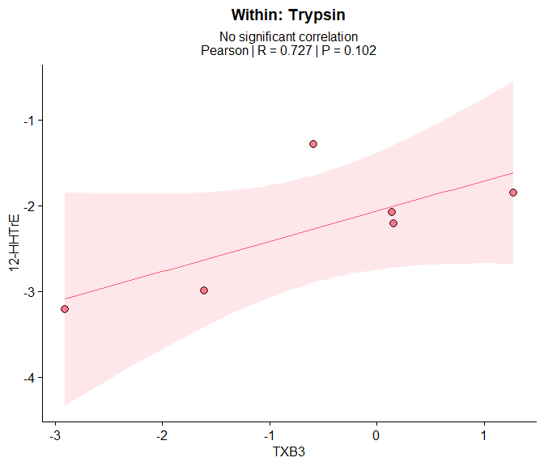

Alternatively, the function `cor_between_oxy` allows comparison of the log<sub>2</sub>-transformed abundance of a single oxylipin between two experimental groups:

```r
cor_between_oxy(staRoxy_object,
                oxylipin = "TXB3",
                group1 = "Scraper",
                group2 = "Trypsin")
```

```
#>
#> ── Inter-group Correlation Analysis ────────────────────────────────────────────
#> ℹ Lipid: 'TXB3' | Comparison: 'Scraper' vs. 'Trypsin'
#> ℹ Method: PEARSON (Normal=TRUE, Outliers=FALSE)
#> ℹ R = 0.421 | P = 0.406 | Result: No significant correlation
#> ────────────────────────────────────────────────────────────────────────────────
```

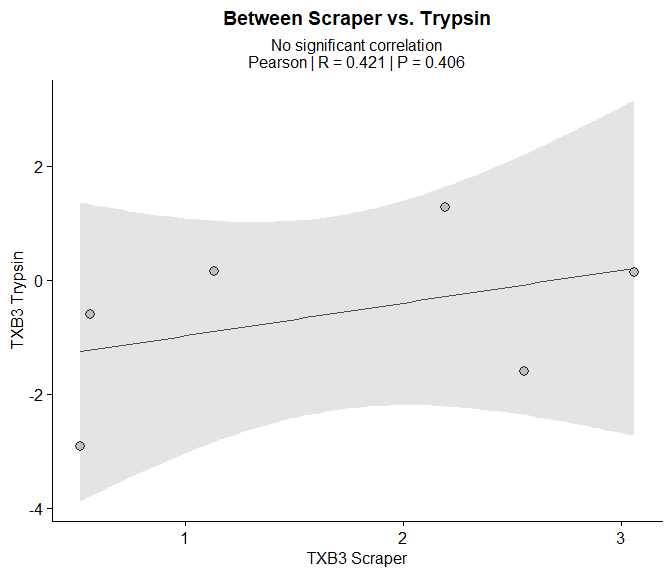

**Note:** Both functions assess normality and outliers to automatically select the appropriate correlation method (Pearson or Spearman) when `method = "auto"` (default). Alternatively, the method can be specified manually (`"pearson"` or `"spearman"`).

## Loading Pattern Dissimilarity Analysis

The `staRoxy` package provides a method to assess the stability of biological architecture between two conditions by comparing oxylipin contributions to principal component structure. While a conventional PCA focuses on sample clustering, the `loading_dissimilarity` function evaluates whether the influence of individual oxylipins on the global profile changes between groups.

For each group $g \in \{1, 2\}$, the loadings ($L$) of principal component $i$ (default: **PC1**, specified by `pc_index = 1`) are extracted as:

$$L_{g,i} = [w_{1,i}, w_{2,i}, \dots,
w_{j,i}, \dots, w_{n,i}]^T$$

Here, $L_{g,i}$ denotes the loading vector for group $g$ and component $i$, $w_j$ represents the loading of the $j$-th oxylipin, $n$ is the number of oxylipins shared between groups after filtering, and $T$ denotes the transpose operator.

Similarity between groups is quantified by correlating the loading vectors using Pearson or Spearman correlation (`method = "auto"` by default). The resulting global similarity metric ($R^2$) is defined as:

$$R^2 = \text{cor}(L_{1,i},
L_{2,i})^2$$

This function performs PCA independently for each group. Because **Eigenvector** signs in PCA are arbitrary, the function automatically detects and corrects axis inversion by reflecting one component when necessary, ensuring meaningful comparisons. If $\text{cor}(L_{1,i}, L_{2,i}) < 0$, the sign of $L_{2,i}$ is internally inverted to ensure that comparisons reflect the magnitude of association.

**Note:** This approach is conceptually related to **Tucker’s Congruence Coefficient ($\phi$)**, a standard metric of factor similarity [7].

High correlation indicates that oxylipin contributions are preserved between groups (stable biological structure), whereas low correlation suggests a reorganization of lipid relationships, where oxylipins may change their relative importance or interaction patterns.

**Divergence** is defined as:

$$\text{Divergence} = 1 - R^2$$

Statistical significance is assessed using a **Fisher** $Z$-transformation to test whether the observed correlation ($r_{obs}$) differs from a predefined stability threshold (`r_stability`, default = 0.6):

$$z = \text{atanh}(r) = \frac{1}{2} \ln
\left( \frac{1 + r}{1 - r} \right)$$

Where:

- $z$: Fisher-transformed correlation coefficient (Fisher’s $z$-score).
- $r$: Original correlation coefficient.
- $\ln$: Natural logarithm.

$$Z = \frac{z_{obs} -
z_{stability}}{SE}$$

Where:

- $Z$: Test statistic (standard score).
- $z_{obs}$: Transformed observed correlation between the sample profile and the group mean profile.
- $z_{stability}$: Transformed stability threshold (default = 0.6, representing the lower bound of a moderate-to-strong correlation).
- $SE$: Standard error of the Fisher transformation.
- $n$: Number of oxylipins (data pairs) used in the correlation.

The $P$-value for divergence is then computed from the standard normal distribution:

$$P(\text{div}) = \Phi(Z)$$
Where:

- $P(\text{div})$: Probability of observing a profile correlation equal to or lower than $r_{obs}$, under the null hypothesis that the sample maintains at least the expected stability ($r \ge r_{stability}$) relative to its biological group.
- $\Phi$: Cumulative distribution function of the standard normal distribution.

In addition, `loading_dissimilarity` generates a scatter plot comparing loadings between groups. Points are colored according to **ΔLoading**, and oxylipins with ΔLoading ≥ `threshold` (default = 0.3) are labeled. Features in quadrants **II** and **IV** represent oxylipins with the strongest divergence in contribution between groups:

```r
loading_dissimilarity(staRoxy_object,
                      group1 = "Scraper",
                      group2 = "Trypsin",
                      pc_index = 1)
```

```
#> ! Removed 1 oxylipin with zero variance/data in at least one group.
#> ✔ Filtering complete: 6/7 oxylipins retained.
#> ℹ Imputing via 'minprob': assuming missingness is due to low concentration (MNAR).
#>
#> ── Loading Pattern Dissimilarity Analysis ──────────────────────────────────────
#> ℹ Comparison: 'Scraper' vs 'Trypsin' (PC1)
#> ℹ Method: PEARSON (Normal=TRUE, Outliers=FALSE)
#> ! Reflection: Eigenvector sign was inverted to maximize congruence.
#> ℹ Correlation (R): 0.5 | Global Congruence (R²): 25%
#> ℹ Divergence (1-R²): 75% | Significance: P(div) = 0.402
#> ────────────────────────────────────────────────────────────────────────────────
```

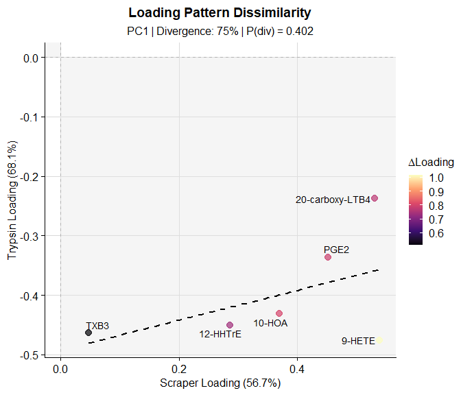

**Note:** Missing values (`NA`) are handled through a multi-step quality control pipeline. Oxylipins are retained only if they have valid measurements in at least 50% of samples (≥50%) in at least one experimental group (user-adjustable). Missingness is assessed via the `plot_na_diagnostic` function, distinguishing between Missing Not At Random (MNAR) and Missing At Random (MAR). For MNAR-type oxylipins, missing values values are imputed using the group-wise arithmetic mean (equivalent to the geometric mean on the log<sub>2</sub> scale). When an entire group lacks detection, values are imputed as below the Limit of Detection (LOD) or failed to meet the Limit of Quantification (LOQ) criteria, using the global minimum for that oxylipin, with stochastic noise sampled from a normal distribution (10% of the global standard deviation) to preserve variance and ensure numerical stability. For MAR-type oxylipins, missing values are imputed using a Random Forest approach (via the `missForest` package), leveraging the global metabolic profile. Group-exclusive oxylipins and those with insufficient variance across groups are excluded from multivariate analyses by default, preventing artificial clustering and ensuring that models reflect robust biological patterns.

## Precursor Identification and Enrichment Analysis

It is possible to classify and quantify the number of oxylipins belonging to each precursor class using the `classify_oxy` function:

```r
classify_oxy(staRoxy_object,
             return_mode = "summary")
```

```
#>
#> ── Oxylipin Classification Summary ─────────────────────────────────────────────
#> ℹ Counts represent unique species detected per precursor/group.
#>       Precursor Scraper Trypsin Total_Unique_Detected
#>  ARA (20:4 n-6)       5       4                     5
#>  EPA (20:5 n-3)       1       1                     1
#>   OA (18:1 n-9)       1       1                     1
```

The `return_mode = "summary"` argument (default) can be set to `"species"` to return a binary table, where $1$ indicates **Presence** and $0$ indicates **Absence** within each group:

```r
classify_oxy(staRoxy_object,
             return_mode = "species")
```

```
#>
#> ── Species Presence/Absence Matrix ─────────────────────────────────────────────
#> ℹ 1 = Presence (detected in group) | 0 = Absence
#>              Lipid      Precursor Scraper Trypsin
#>           12-HHTrE ARA (20:4 n-6)       1       1
#>  1a,1b-dihomo-PGE2 ARA (20:4 n-6)       1       0
#>    20-carboxy-LTB4 ARA (20:4 n-6)       1       1
#>             9-HETE ARA (20:4 n-6)       1       1
#>               PGE2 ARA (20:4 n-6)       1       1
#>               TXB3 EPA (20:5 n-3)       1       1
#>             10-HOA  OA (18:1 n-9)       1       1
```

The function `oxy_ora` performs an **Over-representation Analysis (ORA)** to determine whether the diversity of oxylipins detected in the analyzed groups deviates from the expected biological distribution.

ORA is performed using a **hypergeometric test** (one-vs-all) following established approaches in the literature [8]. This analysis compares the observed diversity of each precursor class with its theoretical frequency in the reference universe (125 oxylipins by defalt) [1]. The enrichment magnitude is summarized by the **Enrichment Score (**$ES$), calculated as:

$$ES = \frac{k / n}{K / N}$$

Where:

- $k$: Number of oxylipin species from precursor class $i$ detected in the group.
- $n$: Total number of distinct oxylipin species detected in the group.
- $K$: Total number of oxylipin species from precursor class $i$ present in the reference universe.
- $N$: Total size of the reference universe.

An $ES > 1$ indicates that a precursor class is over-represented in the analyzed group relative to the reference universe, whereas $ES < 1$ indicates under-representation.

The statistical significance of the enrichment is determined using the hypergeometric test:

$$P(X \geq k) = \sum_{i=k}^{\min(n, K)}
\frac{\binom{K}{i} \binom{N-K}{n-i}}{\binom{N}{n}}$$

Where:

- $\sum_{i=k}^{\min(n, K)}$ represents the cumulative probability of observing $k$, $k+1$, up to the maximum possible number of oxylipins from the precursor class, corresponding to the upper tail probability used to compute the $P$-value.
- $\binom{K}{i}$ represents the number of combinations for selecting $i$ oxylipins from the precursor class within the reference universe.
- $\binom{N-K}{n-i}$ represents the number of combinations for selecting the remaining oxylipins that do not belong to that precursor class.
- $\binom{N}{n}$: represents the total number of possible combinations for selecting $n$ oxylipins from the universe of size $N$.

In addition, the function generates a **Precursor Enrichment** plot, which displays the $ES$ for each precursor class across groups.

```r
oxy_ora(staRoxy_object)
```

```
#>
#> ── Detailed Over-representation analysis (ORA) ─────────────────────────────────
#> ℹ No significant precursor ENRICHMENT detected.
#> ────────────────────────────────────────────────────────────────────────────────
```

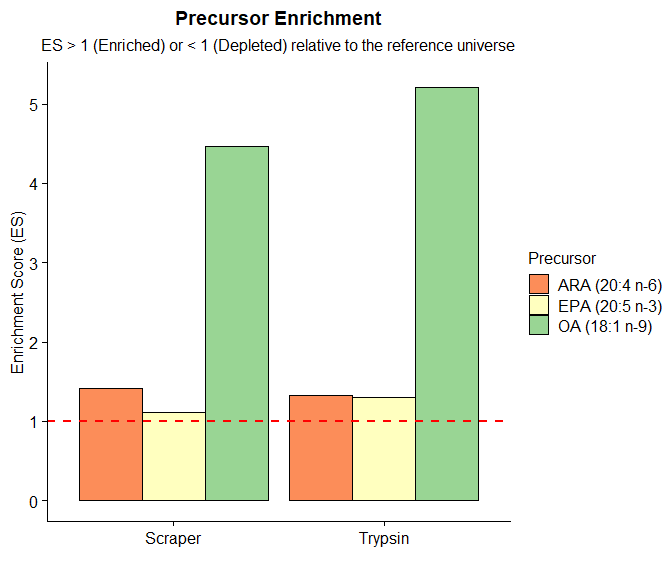

**Note:** ORA can also be performed between two specific groups when more than two experimental groups are present. This can be achieved using the argument `compare_two_groups = TRUE` and specifying the groups with the arguments `group1` and `group2`.

## Adaptation to Other Omics Data

Although originally developed for oxylipin profiling [1], `staRoxy` can be readily adapted to other omics datasets, including transcriptomics, proteomics, and metabolomics. With the exception of `classify_oxy`and `oxy_ora`, all functions can be applied to these data types.

## R Package Dependencies

`staRoxy` depends on several widely accessible packages:

- **Core data manipulation and infrastructure:** `dplyr`, `tidyr`, `tibble`, `data.table`, `stringr`, `forcats`, `readxl`.
- **Statistical modeling and analysis:** `limma`, `mgcv`, `vegan`.
- **Missing data imputation:** `missForest`.
- **Visualization:** `ggplot2`, `ggrepel`, `ggsignif`, `ggiraphExtra`, `ComplexHeatmap`, `circlize`, `viridis`, `RColorBrewer`, `cowplot`, `scales`.
- **Utilities and graphical system:** `grid`, `cli`.